```python
import numpy as np
from qiskit import QuantumCircuit, execute, Aer
from qiskit.visualization import plot_histogram
```

```python
def simulate():
    #faz as simulações e plota um grafico com o resultado das probabilidades
    simulator = Aer.get_backend('qasm_simulator')
    job = execute(circuit, simulator, shots=1000)
    result = job.result()
    counts = result.get_counts(circuit)
    return plot_histogram(counts)
```

# Se colocamor três qubits em superposição a probabilidade de cada um deles colapsar em 1 ou 0 é aleatoria

```python
circuit = QuantumCircuit(3,3)
circuit.h(0)
circuit.h(1)
circuit.h(2)
circuit.measure([0,1,2], [0,1,2])
circuit.draw()
```

```
     ┌───┐┌─┐
q_0: ┤ H ├┤M├──────
     ├───┤└╥┘┌─┐
q_1: ┤ H ├─╫─┤M├───
     ├───┤ ║ └╥┘┌─┐
q_2: ┤ H ├─╫──╫─┤M├
     └───┘ ║  ║ └╥┘
c_0: ══════╩══╬══╬═
              ║  ║
c_1: ═════════╩══╬═
                 ║
c_2: ════════════╩═
```

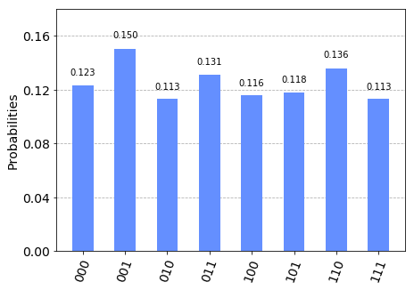

```python
simulate()
```

# Vamos criar o estado de Bell em dois qubits: coloca-se um qubit em superposição e emaranha-o a outro

```python
circuit = QuantumCircuit(3,3)
circuit.h(0)
circuit.cx(0,1)
circuit.measure([0,1,2], [0,1,2])
circuit.draw()
```

```
     ┌───┐     ┌─┐
q_0: ┤ H ├──■──┤M├───
     └───┘┌─┴─┐└╥┘┌─┐
q_1: ─────┤ X ├─╫─┤M├
      ┌─┐ └───┘ ║ └╥┘
q_2: ─┤M├───────╫──╫─
      └╥┘       ║  ║
c_0: ══╬════════╩══╬═
       ║           ║
c_1: ══╬═══════════╩═
       ║
c_2: ══╩═════════════
```

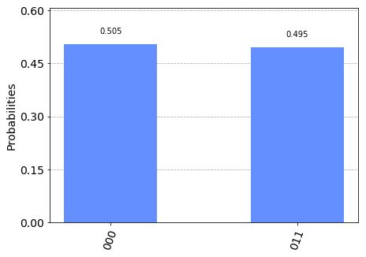

```python
simulate()
```

# Vamos colocar três qubits emaranhados para ver se a probabilidade de colapsarem em 1 é também praticamente definitiva

```python
circuit = QuantumCircuit(3,3)
circuit.h(0)
circuit.ccx(0,1,2)
circuit.measure([0,1,2], [0,1,2])
circuit.draw()
```

```
     ┌───┐     ┌─┐
q_0: ┤ H ├──■──┤M├──────
     └───┘  │  └╥┘┌─┐
q_1: ───────■───╫─┤M├───
          ┌─┴─┐ ║ └╥┘┌─┐
q_2: ─────┤ X ├─╫──╫─┤M├
          └───┘ ║  ║ └╥┘
c_0: ═══════════╩══╬══╬═
                   ║  ║
c_1: ══════════════╩══╬═
                      ║
c_2: ═════════════════╩═
```

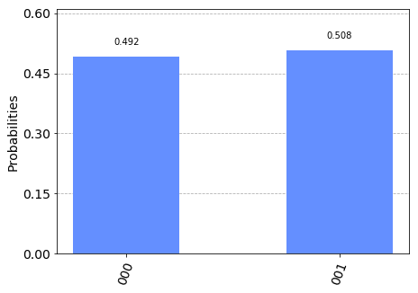

```python
simulate()
```

Como podemos ver, a probabilidade do segundo qubit colapsar em 1 é praticamente inexistente já que ele não está em superposição, e, consequentemente a do terceiro colapsar em 1 também acaba sendo inexistente já que o GATE CCX aplica um not no alvo se os dois anteriores forem 1.

e se colocarmos o segundo também em superposição?

```python
circuit = QuantumCircuit(3,3)
circuit.h(0)
circuit.h(1)
circuit.ccx(0,1,2)
circuit.measure([0,1,2], [0,1,2])
circuit.draw()
```

```
     ┌───┐     ┌─┐
q_0: ┤ H ├──■──┤M├──────
     ├───┤  │  └╥┘┌─┐
q_1: ┤ H ├──■───╫─┤M├───
     └───┘┌─┴─┐ ║ └╥┘┌─┐
q_2: ─────┤ X ├─╫──╫─┤M├
          └───┘ ║  ║ └╥┘
c_0: ═══════════╩══╬══╬═
                   ║  ║
c_1: ══════════════╩══╬═
                      ║
c_2: ═════════════════╩═
```

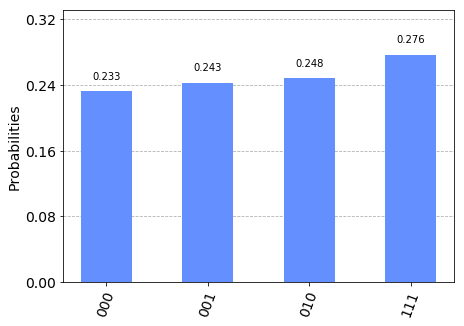

```python
simulate()
```

Como esperado, a probabilidade do terceiro qubit colapsar em 1 aumentou consideravelmente já que tendo os dois primeiros qubits em superposição eles poderão provavelmente colapsar em 1, e, consequentemente o terceiro colapsar em 1 já que está emaranhado aos dois primeiros

# E se, colocarmos apenas o primeiro em superposição mas emaranhado com o segundo, e o terceiro emaranhado aos dois primeiros?

```python
circuit = QuantumCircuit(3,3)
circuit.h(0)
circuit.cx(0,1)
circuit.ccx(0,1,2)
circuit.measure([0,1,2], [0,1,2])
circuit.draw()
```

```
     ┌───┐          ┌─┐
q_0: ┤ H ├──■────■──┤M├──────
     └───┘┌─┴─┐  │  └╥┘┌─┐
q_1: ─────┤ X ├──■───╫─┤M├───
          └───┘┌─┴─┐ ║ └╥┘┌─┐
q_2: ──────────┤ X ├─╫──╫─┤M├
               └───┘ ║  ║ └╥┘
c_0: ════════════════╩══╬══╬═
                        ║  ║
c_1: ═══════════════════╩══╬═
                           ║
c_2: ══════════════════════╩═
```

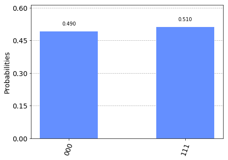

```python
simulate()
```

chega a ser intuitivo, a probabilidade do primeiro qubit colapsar em 1 é de 50% se ele está em superposição, se ele colapsar em 1 irá transferir esse estado para o segundo qubit, e, se os três estão emaranhados, esse estado será transferido também ao terceiro, logo, 50% de change dos 3 qubits colapsarem em 1 e 50% dos três colapsarem em 0